# Lab 3: COVID-19

Ecosystem Science and Sustainabilty 330

Author

Genesis Lacy

Q1: Easy access to open data is important to provide transparency with the public as well as providing data for those interested in the results and for people who are interested and/or are working on data analysis.

```r
url = "https://raw.githubusercontent.com/nytimes/covid-19-data/master/us-counties.csv"
read.csv(url)
```

[output not shown]

[output cut: 33320 more lines]

Q2: Creating a subset to generate cumulative cases and new cases for the top 5 counties.

```r
library(tidyverse); library(flextable)
data = read_csv('https://raw.githubusercontent.com/nytimes/covid-19-data/master/us-counties.csv')
my.date <- as.Date("2022-02-01")
my.state <- "Colorado"

co_data <- data %>%
  filter(state == my.state) %>%
  arrange(county, date) %>%
  group_by(county) %>%
  mutate(new_cases = cases - lag(cases, default = first (cases)),
        new_deaths = deaths - lag (deaths, default = first(deaths))) %>%
  ungroup()
```

```r
latest_data <- co_data %>%
  filter(date == my.date)

top5_cumulative_cases <- latest_data %>%
  arrange(desc(cases)) %>%
  slice_head(n = 5) %>%
  select(county, cases)

top5_new_cases <- latest_data %>%
  arrange(desc(new_cases)) %>%
  slice_head(n = 5) %>%
  select(county, new_cases)

top5_cumulative_cases %>%
  flextable() %>%
  set_caption("Top 5 counties by cumulative cases")
```

| county | cases |
| --- | --- |
| El Paso | 170,673 |
| Denver | 159,022 |
| Arapahoe | 144,255 |
| Adams | 126,768 |
| Jefferson | 113,240 |

```r
top5_new_cases %>%
  flextable() %>%
  set_caption("Top 5 counties by new cases")
```

| county | new_cases |
| --- | --- |
| El Paso | 630 |
| Arapahoe | 401 |
| Denver | 389 |
| Adams | 326 |
| Jefferson | 291 |

Q3:Normalizing Data - adding population data

```r
pop_url <- 'https://www2.census.gov/programs-surveys/popest/datasets/2020-2023/counties/totals/co-est2023-alldata.csv'
pop_data <- read_csv(pop_url)
pop_data <- pop_data %>%
  mutate(
    STATE = str_pad(as.character(STATE), 2, pad = "0"),
    COUNTY = str_pad(as.character(COUNTY), 3, pad = "0"),
    FIPS = paste0(STATE, COUNTY)

  ) %>%
  filter(COUNTY != "000") %>%
  select(FIPS,STNAME,CTYNAME, contains("2021"))

glimpse(pop_data)
```

```
Rows: 3,144
Columns: 19
$ FIPS                  <chr> "01001", "01003", "01005", "01007", "01009", "01…
$ STNAME                <chr> "Alabama", "Alabama", "Alabama", "Alabama", "Ala…
$ CTYNAME               <chr> "Autauga County", "Baldwin County", "Barbour Cou…
$ POPESTIMATE2021       <dbl> 59203, 239439, 24533, 22359, 59079, 10143, 18890…
$ NPOPCHG2021           <dbl> 288, 6212, -436, 171, -28, -86, -135, -565, -163…
$ BIRTHS2021            <dbl> 686, 2337, 270, 240, 654, 111, 227, 1250, 392, 2…
$ DEATHS2021            <dbl> 696, 2948, 390, 325, 875, 160, 297, 1843, 592, 4…
$ NATURALCHG2021        <dbl> -10, -611, -120, -85, -221, -49, -70, -593, -200…
$ INTERNATIONALMIG2021  <dbl> 15, 105, 0, 1, 9, 1, 5, 12, 22, 7, 20, 1, 0, -1,…
$ DOMESTICMIG2021       <dbl> 242, 6972, -313, 254, 141, -42, -75, -70, -6, 28…
$ NETMIG2021            <dbl> 257, 7077, -313, 255, 150, -41, -70, -58, 16, 29…
$ RESIDUAL2021          <dbl> 41, -254, -3, 1, 43, 4, 5, 86, 21, 2, 18, 7, 8, …
$ GQESTIMATES2021       <dbl> 484, 3351, 2248, 1994, 616, 1578, 285, 5407, 856…
$ RBIRTH2021            <dbl> 11.615503, 9.888589, 10.908650, 10.775136, 11.06…
$ RDEATH2021            <dbl> 11.78483, 12.47392, 15.75694, 14.59133, 14.80717…
$ RNATURALCHG2021       <dbl> -0.1693222, -2.5853351, -4.8482890, -3.8161941, …
$ RINTERNATIONALMIG2021 <dbl> 0.25398330, 0.44428836, 0.00000000, 0.04489640, …
$ RDOMESTICMIG2021      <dbl> 4.0975973, 29.5007468, -12.6459537, 11.4036860, …
$ RNETMIG2021           <dbl> 4.3515806, 29.9450352, -12.6459537, 11.4485824, …
```

After Modification we’re only looking at columns we filtered to contain “2021” and “name”. A lot of the values are doubles and there are also a few characters.

```r
co_data <- co_data %>%
  left_join(pop_data, by = c("fips" = "FIPS"))

co_data <- co_data %>%
  mutate(
    pop_2021 = coalesce(POPESTIMATE2021, 1) ,
    cumulative_per_capita = cases / pop_2021,
    new_cases_per_capita = new_cases / pop_2021,
    new_deaths_per_capita = new_deaths / pop_2021
  )

  latest_data <- co_data %>%
    filter(date == my.date)

top_cumulative_per_capita <- latest_data%>%
  arrange(desc(cumulative_per_capita))%>%
  slice_head(n = 5)%>%
  select(county, cumulative_per_capita)%>%
  flextable()%>%
  set_caption("Top 5 Counties by Cumulative Cases per Capita")

top_new_per_capita <- latest_data%>%
  arrange(desc(new_cases_per_capita))%>%
  slice_head(n = 5)%>%
  select(county, new_cases_per_capita)%>%
  flextable()%>%
  set_caption("Top 5 Counties by New Cases per Capita")

top_cumulative_per_capita
```

| county | cumulative_per_capita |
| --- | --- |
| Crowley | 0.5117698 |
| Bent | 0.4118749 |
| Pitkin | 0.3429659 |
| Lincoln | 0.3424082 |
| Logan | 0.3047701 |

```r
top_new_per_capita
```

| county | new_cases_per_capita |
| --- | --- |
| Crowley | 0.009764603 |
| Bent | 0.004120622 |
| Sedgwick | 0.003869304 |
| Washington | 0.002875924 |
| Las Animas | 0.002651039 |

Q4: Rolling Thresholds - Filtering the merged COVID/ Population data to only include the past 14 days.

```r
library(tidyverse)
my.date <- as.Date("2022-02-01")
date_14_days_ago <- my.date - 14

co_last_14 <- co_data%>%
  filter(date >= date_14_days_ago & date <= my.date)
county_14d_summary <- co_last_14%>%
  group_by(county)%>%
  summarize(
    total_new_cases = sum(new_cases, na.rm = TRUE),
    population = first(pop_2021),
    new_cases_per_100k = (total_new_cases / population) * 100000) %>%

ungroup()

top5_new_cases <- county_14d_summary%>%
  arrange(desc(new_cases_per_100k)) %>%
  slice_head(n = 5)%>%
  select(county, new_cases_per_100k) %>%
  flextable() %>%
  set_caption("Top 5 Counties by New Cases per 100,000 residents in the last 14 days")

watch_list_count <- county_14d_summary%>%
  filter(new_cases_per_100k > 100) %>%
  nrow()

top5_new_cases
```

| county | new_cases_per_100k |
| --- | --- |
| Crowley | 5,475.153 |
| Lincoln | 3,763.932 |
| Alamosa | 3,757.766 |
| Mineral | 3,336.921 |
| Conejos | 3,336.850 |

Counties that meet the watch list conditions- 64 total counties.

```r
print(watch_list_count)
```

```
[1] 64
```

Q5: Death toll- finding the ratio of total COVID deaths per county in 2021 of all recorded deaths. Create a plot that visualizes all counties where COVID deaths account for 20% or more of the annual death toll.

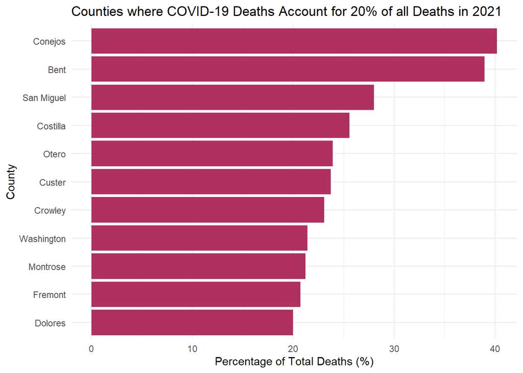

```r
library(dplyr)

covid_deaths_2021 <- co_data %>%
  filter(lubridate::year(date) == 2021) %>%
  group_by(fips, county) %>%
  summarize(total_covid_deaths = sum(new_deaths, na.rm = TRUE)) %>%
mutate(fips = as.character(fips))
covid_deaths_2021 <- covid_deaths_2021 %>%
  mutate(fips = as.character(fips))

pop_data <- pop_data %>%
  mutate(FIPS = as.character(FIPS))


death_data <- covid_deaths_2021%>%
  left_join(pop_data%>% select(FIPS, CTYNAME, DEATHS2021), by
             = c("fips" = "FIPS"))

death_data <- death_data %>%
   mutate(covid_death_pct = (total_covid_deaths /DEATHS2021) * 100) %>%
   filter(!is.na(covid_death_pct))

high_covid_impact <- death_data%>%
 filter(covid_death_pct >= 20)


library(ggplot2)

ggplot(high_covid_impact, aes(x = reorder(county,covid_death_pct), y = covid_death_pct)) +
  geom_bar( stat = "identity", fill = "maroon")+
  coord_flip()+
  labs(
    title = "Counties where COVID-19 Deaths Account for 20% of all Deaths in 2021",
x = "County",
y = "Percentage of Total Deaths (%)"
  ) +
  theme_minimal()
```

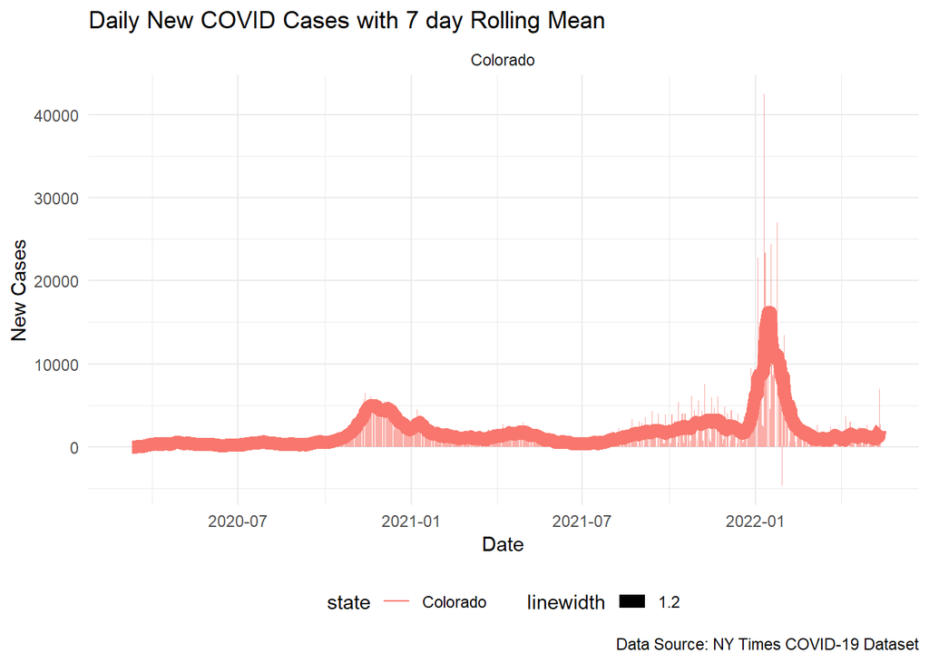

```r
library(dplyr)
library(zoo)
selected_states <- c("New York", "Colorado", "Alabama", "Ohio")

state_covid_data <- co_data %>%
  filter(state %in% selected_states) %>%
  group_by(state, date) %>%
  summarize(
    total_cases = sum(cases, na.rm = TRUE),
    .groups = "drop"
  )%>%
  group_by(state) %>%
  arrange(date, .by_group = TRUE) %>%
  mutate(
    total_new_cases = total_cases - lag(total_cases, default = first(total_cases)),
    rolling_avg_new_cases = rollmean(total_new_cases, k = 7, fill = NA, align = "right")) %>%

ungroup()

ggplot(state_covid_data, aes(x = date, y = total_new_cases, fill = state)) +
  geom_col(show.legend = FALSE, alpha = 0.6)+
  geom_line(aes(y = rolling_avg_new_cases, color = state, linewidth = 1.2)) +
  facet_wrap(~state, scales = "free_y") +
  theme_minimal()+
  labs(
    title = "Daily New COVID Cases with 7 day Rolling Mean",
  x = "Date",
  y = "New Cases",
  caption = "Data Source: NY Times COVID-19 Dataset",
  )+
theme(legend.position = "bottom")
```

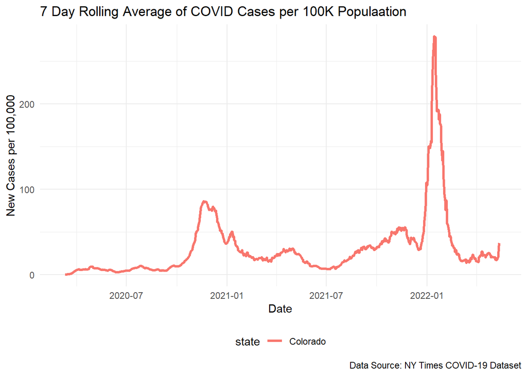

```r
state_pop_data <- pop_data %>%
  filter(STNAME %in% selected_states) %>%
  group_by(STNAME) %>%
  summarize(population = sum(POPESTIMATE2021, na.rm = TRUE), .groups = "drop") %>%
  rename(state = STNAME)

state_covid_per_capita <- state_covid_data%>%
  left_join(state_pop_data, by = "state") %>%
  mutate(
    cases_per_100k = (total_new_cases / population) * 100000,
    rolling_avg_per_100k = rollmean(cases_per_100k, k = 7, fill = NA, align = "right")
  )


ggplot(state_covid_per_capita, aes(x = date, y = rolling_avg_per_100k, color = state))+
  geom_line(size = 1.2) +
  theme_minimal()+
    labs(
      title = "7 Day Rolling Average of COVID Cases per 100K Populaation",
      x = "Date",
      y = "New Cases per 100,000",
      caption = "Data Source: NY Times COVID-19 Dataset"
    )+
theme(legend.position = "bottom")
```

The influence scaling the population had on the analysis: I think having the scale of 100K people is good to keep the ratio the same across the board but I also think the scale might need to be re arranged based on population numbers per state.

Does it make some states look better? Worse? How so? I think that the scale can make it more difficult to understand the magnitude of COVID cases again because the data is heavily reliant on population.

Q7:Calculating the weighted mean center of the COVID outbreak in the US

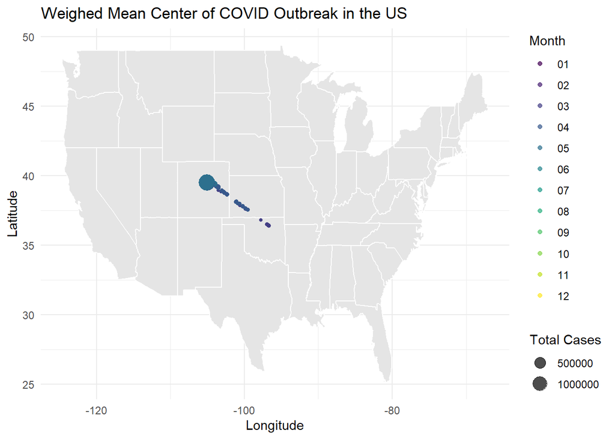

```r
library(dplyr)
library(readr)

centroids <- read_csv("https://raw.githubusercontent.com/mikejohnson51/csu-ess-330/refs/heads/main/resources/county-centroids.csv")
co_data <- co_data%>%
  mutate(fips = as.character(fips)) %>%
  left_join(centroids, by = "fips")

co_data <- co_data %>%
  select(date,fips,cases,deaths,state, county,LON,LAT)

wmc_data <- co_data %>%
  group_by(date) %>%
  summarize(
  total_cases = sum(cases, na.rm = TRUE),
  weighted_lon = sum(LON * cases, na.rm = TRUE) / total_cases,
  weighted_lat = sum(LAT * cases, na.rm = TRUE) / total_cases,
  month = format(date,"%m"),
  .groups = "drop")
ggplot() +
  borders("state", fill = "gray90", colour = "white") +
  geom_point(
    data = wmc_data,
    aes(x = weighted_lon, y = weighted_lat, color = month, size = total_cases),
    alpha = 0.7
  )+
  scale_colour_viridis_d() +
  theme_minimal()+
  labs(
    title = "Weighed Mean Center of COVID Outbreak in the US",
    x = "Longitude",
    y = "Latitude",
    color = "Month",
    size = "Total Cases"
  )
```

Describe the movement of the COVID weighted mean throughout the US and possible drivers of its movement given your knowledge of the outbreak hot spots.